# Class Activity, November 19

## Setup

In this activity, we will work with the `Titanic` data.

Download the activity template: [activity template](https://sta112-f21.github.io/class_activities/ca_lecture_37_template.Rmd)

## Part I

Let’s begin by exploring the relationship between age and survival, broken down by sex and passenger class:

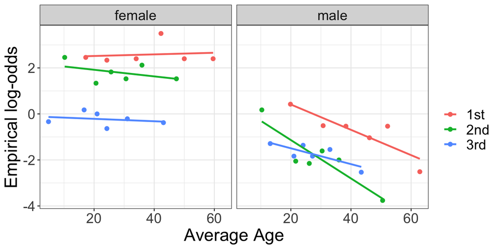

1. A logistic regression model would assume that the relationship between age and the log-odds of survival is linear within each combination of sex and passenger class. Does that assumption look reasonable?
2. Does there appear to be a relationship between age and survival, after accounting for sex and class?
3. Which combination of age, class, and sex appears to have the highest chance of survival? The lowest? Why might that be?

## Part II

Based on the empirical log-odds plot above, we choose the logistic regression model

$$\begin{align}
\log \left( \dfrac{\pi}{1 - \pi} \right) &= \beta_0 + \beta_1 \ \text{IsMale} + \beta_2 \ \text{IsSecondClass} + \beta_3 \ \text{IsThirdClass} + \beta_4 \ \text{Age} \ + \\
& \hspace{0.5cm} \beta_5 \ \text{IsMale} \cdot \text{IsSecondClass} + \beta_6 \ \text{IsMale} \cdot \text{IsThirdClass} \ + \\
& \hspace{0.5cm} \beta_7 \ \text{IsMale} \cdot \text{Age} + \beta_8 \ \text{IsSecondClass} \cdot \text{Age} + \beta_9 \ \text{IsThirdClass} \cdot \text{Age} \ + \\
& \hspace{0.5cm} \beta_{10} \ \text{IsMale} \cdot \text{IsSecondClass} \cdot \text{Age} + \beta_{11} \ \text{IsMale} \cdot \text{IsThirdClass} \cdot \text{Age}
\end{align}$$
where $\pi$ is the probability of survival.

4. Fit the above model (you don’t need to write down the fitted model right now).
5. Using the fitted model, what is the estimated odds ratio of survival for a 40 year old woman in first class vs. a 40 year old man in first class?
6. Does this estimated odds ratio change as age changes?

## Part III

Now let’s consider two questions we could answer using our model.

- Is there a relationship between age and survival, after accounting for sex and class?
- After accounting for sex, does the change in the odds of survival associated with a 1-year increase in age depend on class?
7. For each of these two questions, write down a reduced model that would allow you to address the question with a nested test.